# Délka humeru podle přežití vrabců

Vojtěch Tóth, Cuphead, Mugman

2022-12-08

```r
  K = 4
  L = 4
  M = ((K+L)*47)%%11+1.
```

```
## [1] 3
```

## Úloha 1

> 1. Načtěte datový soubor a rozdělte sledovanou proměnnou na příslušné dvě pozorované skupiny. Stručně popište data a zkoumaný problém. Pro každu skupinu zvlášť odhadněte střední hodnotu, rozptyl a medián příslušného rozdělení.

Dataset, který budeme v tomto úkolu zpracovávat, je case0201. Tento dataset obsahuje 59 záznamů dvou proměnných

Data nasbíral H. Bumpus. Zkoumal, zda uhynulí vrabci postrádají některé fyzické vlastnosti oproti těm, kteří přežili a tím chtěl podpořit teorii přirozeného výběru.

Proměnnou Humerus rozdělíme do dvou skupin podle stavu.

```r
library(Sleuth2)
perished <- subset(case0201, Status=="Perished")$Humerus
survived <- subset(case0201, Status=="Survived")$Humerus
```

Ve skupině Uhynulích máme 24 hodnot, ve skupině přeživších 35.

```r
str(perished)
```

```
##  num [1:24] 659 689 703 702 709 713 720 729 726 726 ...
```

```r
str(survived)
```

```
##  num [1:35] 687 703 709 715 728 721 729 723 728 723 ...
```

Vzorce pro výběrový průměr, rozptyl a pro medián jsou popořadě
$$\bar{X}_n =
\frac{1}{n}\sum^{n}_{i=1}{X_i}$$
,
$$s^2_n =
\frac{1}{n-1}\sum^n_{i=1}{(X_i-\bar{X}_n)^2}$$
,
$$\text{med}(X) =
\begin{cases}
a_{\lfloor \frac{n}{2} \rfloor} & \text{pokud } n\%2=1
\\
\frac{a_{\lfloor \frac{n}{2} \rfloor} + a_{\lceil \frac{n}{2}
\rceil} }{2}
&\text{pokud }n\%2=0 \\
\end{cases}$$
,

my použijeme následující funkce.

```r
mean_per <- mean(perished)
var_per <- var(perished)
med_per <- median(perished)

mean_sur <- mean(survived)
var_sur <- var(survived)
med_sur <- median(survived)
```

Výsledné hodnoty jsou v této tabulce.

[output not shown]

## Úloha 2

> (1b) Pro každou skupinu zvlášť odhadněte hustotu a distribuční funkci pomocí histogramu a empirické distribuční funkce.

Empirická distribuční funkce je definována jako

$$F_n(x)=F_n(x,
X_1,...,X_n)=\frac{1}{n}\sum^{n}_{i=1}{
1\!\!1_{\left \{ x_i\leq x \right \} } }$$

Tedy pro reálnou proměnnou $x$ zjistíme počet hodnot $x_i$, které jsou menší nebo rovny $x$ a podělíme je počtem všech záznamů $n$ dané skupiny. V jazyce R se pro výpočet hodnot používá funkce ecdf, výstup vykreslí funkce plot.

Histogram je sloupcový graf, kde každý sloupec má zvolenou nějakou vhodnou šířku. Výška daných sloupců se získá ze vztahu

$$\frac{m_i}{n\cdot h} =
\frac{\text{počet hodnot uvnitř sloupce}}
{\text{počet všech hodnot}\cdot\text{šířka sloupce}}$$
Funkce hist z daných hodnot zvládne odhadnout nejlepší šířku sloupce a rovnou histogram vykreslí.

### Empirická distribuční funkce a histogram skupiny uhynulích

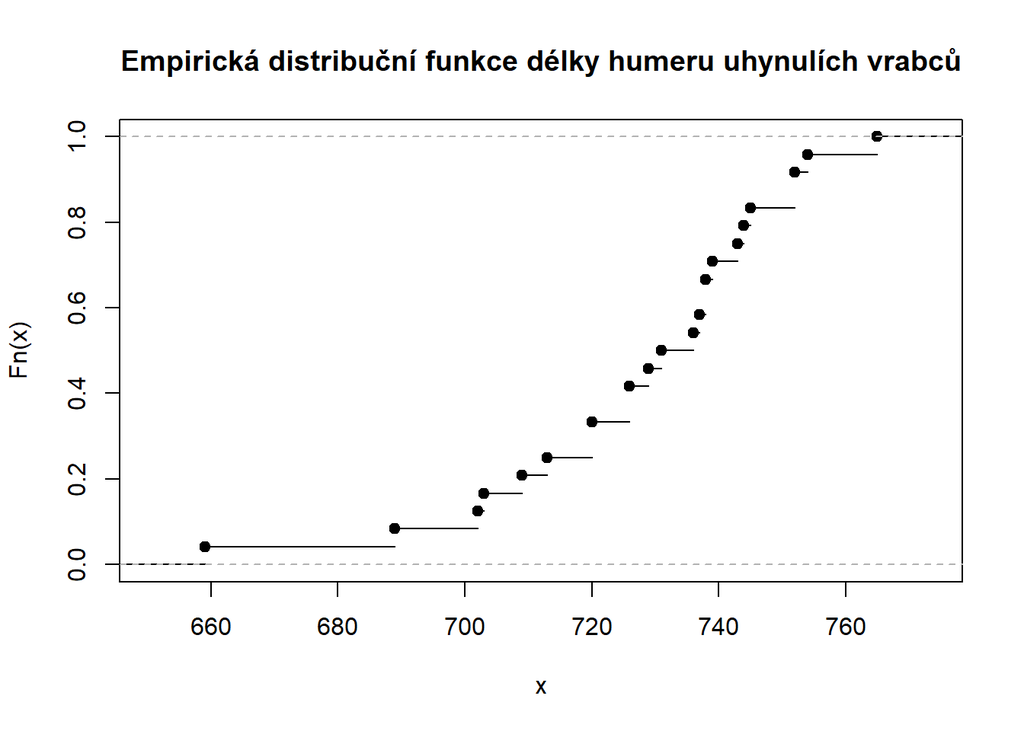

```r
plot(ecdf(perished), main = "Empirická distribuční funkce délky humeru uhynulích vrabců")
```

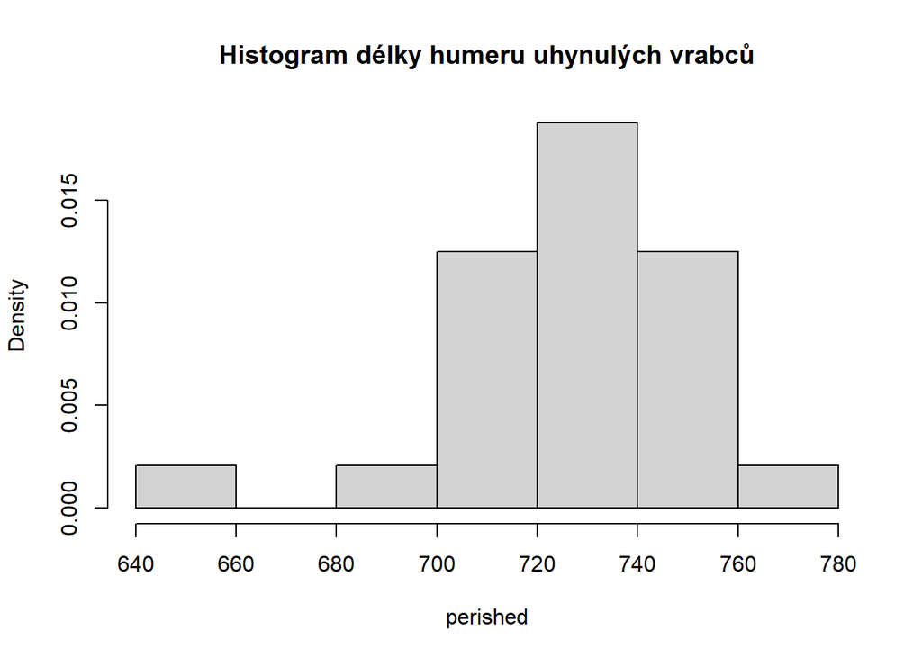

```r
hist(perished, freq = FALSE, main = "Histogram délky humeru uhynulých vrabců" )
```

Lze tvrdit, že délka humeru uhynulých vrabců se řídí normálním rozdělením.

### Empirická distribuční funkce a histogram skupiny přeživších

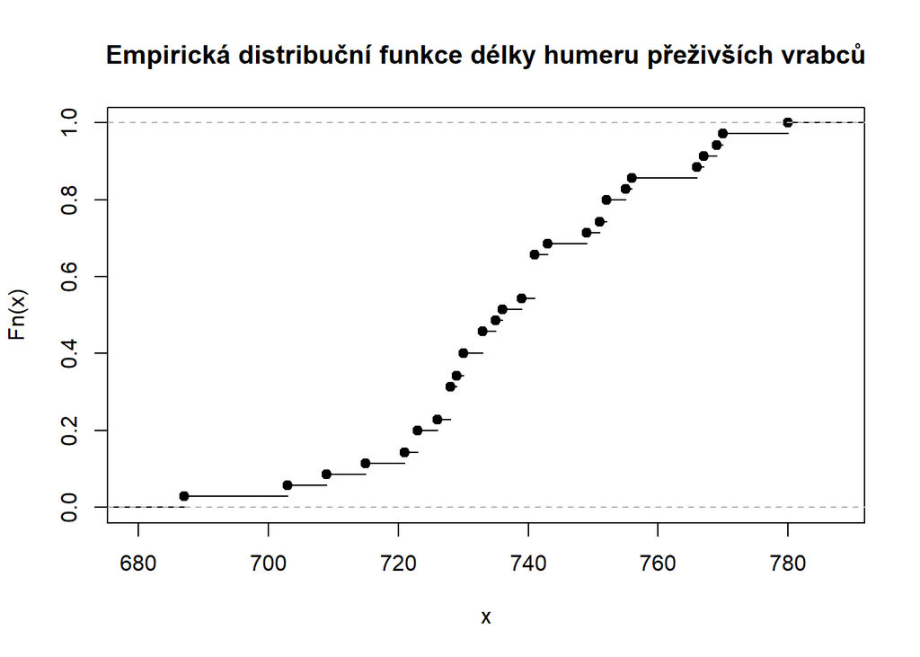

```r
plot(ecdf(survived), main = "Empirická distribuční funkce délky humeru přeživších vrabců")
```

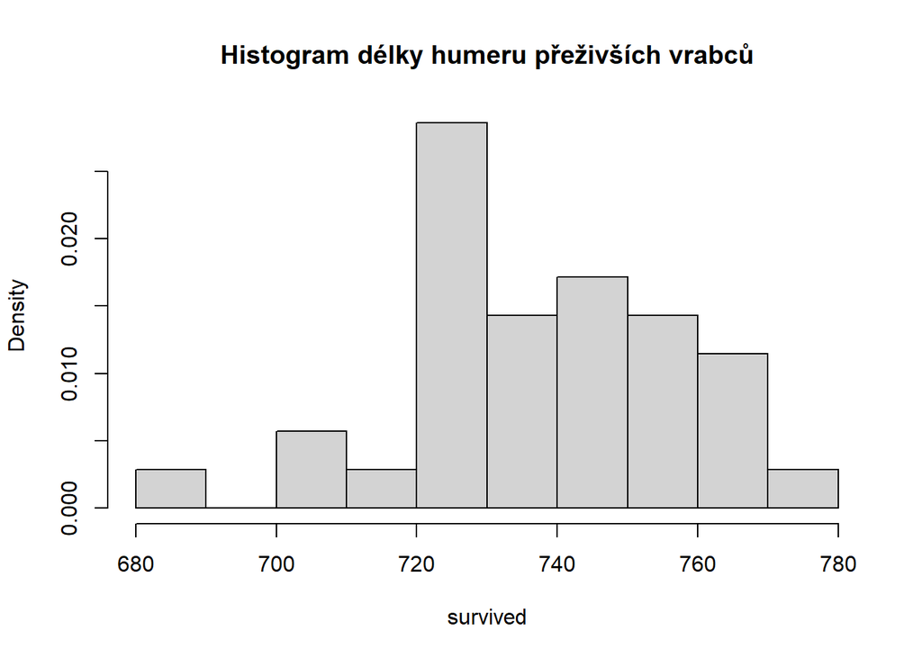

```r
hist(survived, freq = FALSE, main = "Histogram délky humeru přeživších vrabců")
```

Lze tvrdit, že i délka humeru přeživších vrabců se řídí normálním rozdělením.

## Úloha 3

> (3b) Pro každou skupinu zvlášť najděte nejbližší rozdělení: Odhadněte parametry normálního, exponenciálního a rovnoměrného rozdělení. Zaneste příslušné hustoty s odhadnutými parametry do grafů histogramu. Diskutujte, které z rozdělení odpovídá pozorovaným datům nejlépe.

Pro odhad parametrů lze použít balíček `EnvStats`.

### Rovnoměrné rozdělení

Rovnoměrné rozdělení je takové rozdělnení, které má v nějakém intervalu $(a,b)$ konstatní pravděpodobnost, mimo něj je pravděpodobnost rovna 0. Pro hustotu platí

$$f_n(x) = \begin{cases}
\frac{1}{b-a} & \text{pro } x\in (a,b) \\
0 & \text{pro } x\not\in
(a,b) \end{cases}$$

Hledáme tedy odhad parametrů $a$ a $b$. Použijeme funkci `eunif` u které zvolíme momentovou metodu. Získané parametry jsou prvky pole parameters, $a$ na indexu 1, $b$ na indexu 2.

```r
library(EnvStats, warn.conflicts=F, quietly=T)
unif_perished <- eunif( perished, method="mme")$parameters
unif_survived <- eunif( survived, method="mme")$parameters

a_per <- unif_perished[1]
b_per <- unif_perished[2]

a_sur <- unif_survived[1]
b_sur <- unif_survived[2]
```

Výsledné odhady:

|  | Přeživší | Uhynulí |
| --- | --- | --- |
| a | 704.1321897 | 687.9982603 |
| b | 771.8678103 | 767.835073 |

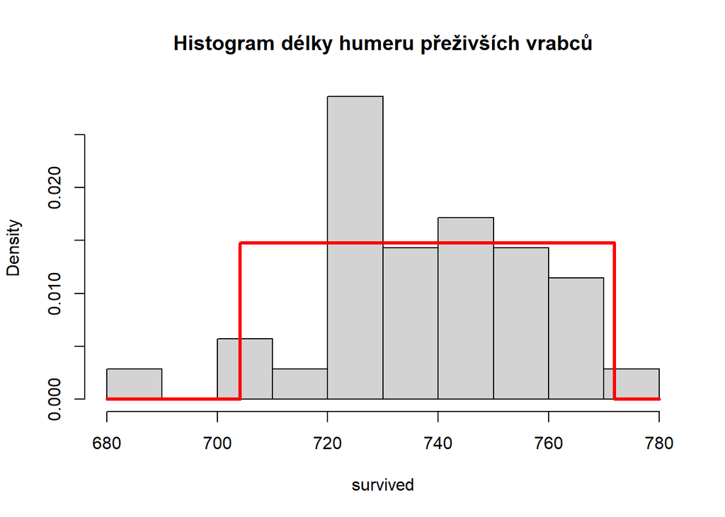

```r
hist(survived, freq = FALSE, main = "Histogram délky humeru přeživších vrabců")
min <- 680
max <- 780
x <- c( min, a_sur, a_sur, b_sur, b_sur, max )
p <- dunif(a_sur, min=a_sur, max=b_sur)
y <- c( 0, 0, p, p, 0, 0)
lines(x, y, col="red", lwd=3)
```

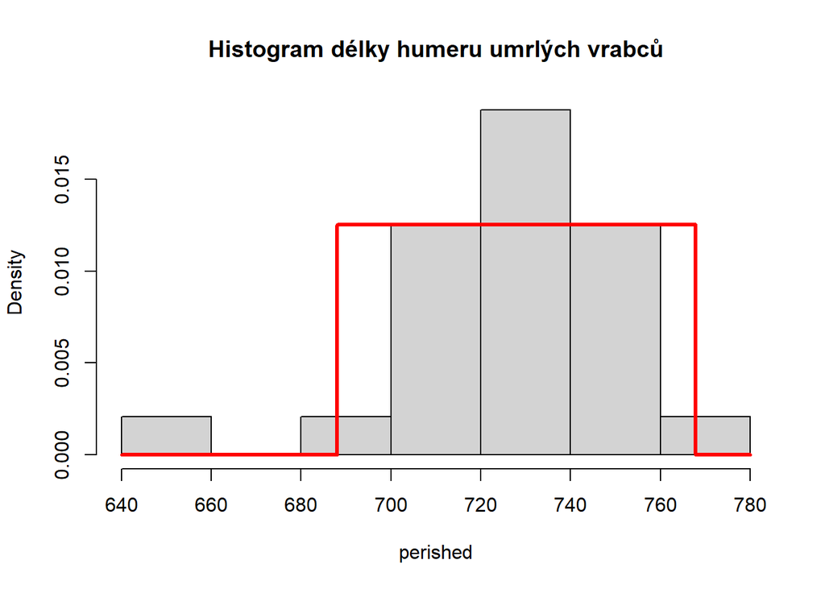

```r
min <- 640
max <- 780
hist(perished, freq = FALSE, main = "Histogram délky humeru umrlých vrabců")
x <- c( min , a_per, a_per, b_per, b_per, max )
p <- dunif(a_per, min=a_per, max=b_per)
y <- c(0, 0, p, p, 0, 0 )
lines(x, y, col="red", lwd=3)
```

## Úloha 4

> (1b) Pro každou skupinu zvlášť vygenerujte náhodný výběr o 100 hodnotách z rozdělení, které jste zvolili jako nejbližší, s parametry odhadnutými v předchozím bodě. Porovnejte histogram simulovaných hodnot s pozorovanými daty.

## Úloha 5

> (1b) Pro každou skupinu zvlášť spočítejte oboustranný 95% konfidenční interval pro střední hodnotu.

## Úloha 6

> (1b) Pro každou skupinu zvlášť otestujte na hladině významnosti 5 % hypotézu, zda je střední hodnota rovná hodnotě K (parametr úlohy), proti oboustranné alternativě. Můžete použít buď výsledek z předešlého bodu, nebo výstup z příslušné vestavěné funkce vašeho softwaru.

## Úloha 7

> (2b) Na hladině významnosti 5 % otestujte, jestli mají pozorované skupiny stejnou střední hodnotu. Typ testu a alternativy stanovte tak, aby vaše volba nejlépe korespondovala s povahou zkoumaného problému.